# PFG-bank: Data Driven Credit Card Design

- Team-lead gitlab id: rsm-s8hua
- Group name: UCSD Undergrad Alumni
- Team member names: Shiyi Hua, Wan Qiu, Siwei Xie, Ziyuan Yan

## Setup

Please complete this Rmarkdown document by answering the questions in `pfg-bank.pdf` on Canvas (week10/). The code block below will load the historical data from exhibits 1 and 2. Please DO NOT change the code used to load the data. Create an HTML (Notebook) file with all your results and comments and push both the Rmarkdown and HTML file to GitLab when you are done. All analysis results MUST be reproducible (i.e., the TA and I must be able to recreate the HTML from the Rmarkdown file without changes or errors).

This is the final group assignment for MGTA 455 and you will be using git and GitLab. If two people edit the same file at the same time you could get what is called a “merge conflict”. git will not decide for you who’s change to accept so the team-lead will have to determine which edits to use. To avoid merge conflicts, always “pull” changes to the repo before you start working on any files. Then, when you are done, save and commit your changes, and then push them to GitLab. Make “pull first” a habit!

```r
exhibit1 <- readxl::read_excel("data/exhibits.xlsx", sheet = "exhibit1")
exhibit2 <- readxl::read_excel("data/exhibits.xlsx", sheet = "exhibit2")
```

## Question answers

### Test Round

```r
## Look for interaction
result <- correlation(
  exhibit1,
  vars = c("apr", "fixed_var", "annual_fee", "bk_score")
)
summary(result)
```

```
Correlation
Data        : exhibit1
Method      : Pearson
Variables   : apr, fixed_var, annual_fee, bk_score
Null hyp.   : variables x and y are not correlated
Alt. hyp.   : variables x and y are correlated
** Variables of type {factor} included without adjustment **

Correlation matrix:
           apr   fixed_var annual_fee
fixed_var  -0.43
annual_fee -0.24  0.30
bk_score    0.33 -0.07     -0.05

p.values:
           apr  fixed_var annual_fee
fixed_var  0.12
annual_fee 0.40 0.29
bk_score   0.25 0.81      0.86
```

#### Comment: Since the absolute values of correlation between each pair of variables are all less than 0.5 (50%), we decide not to include interaction for our design of experiments.

```r
## Design of experiments
result <- doe(
  factors = c(
    "apr; 14.9; 16.8; 19.8",
    "fixed_var; Fixed; Variable",
    "annual_fee; 0; 20",
    "bk_score; 150; 200; 250"
  ),
  seed = 1234
)
summary(result, eff = TRUE, part = TRUE, full = TRUE)
```

```
Experimental design
# trials for partial factorial: 36
# trials for full factorial   : 36
Random seed                   : 1234

Attributes and levels:
apr: 14.9, 16.8, 19.8
fixed_var: Fixed, Variable
annual_fee: 0, 20
bk_score: 150, 200, 250

Design efficiency:
 Trials D-efficiency Balanced
      7        0.368    FALSE
      8        0.276    FALSE
      9        0.751    FALSE
     10        0.705    FALSE
     11        0.507    FALSE
     12        0.892     TRUE
     13        0.813    FALSE
     14        0.792    FALSE
     15        0.726    FALSE
     16        0.678    FALSE
     17        0.622    FALSE
     18        0.965     TRUE
     19        0.911    FALSE
     20        0.869    FALSE
     21        0.821    FALSE
     22        0.852    FALSE
     23        0.848    FALSE
     24        0.922     TRUE
     25        0.883    FALSE
     26        0.846    FALSE
     27        0.914    FALSE
     28        0.888    FALSE
     29        0.862    FALSE
     30        0.905     TRUE
     31        0.908    FALSE
     32        0.896    FALSE
     33        0.865    FALSE
```

[output cut: 112 more lines]

```
    22 16.8  Variable         20      150
    23 16.8  Variable         20      200
    24 16.8  Variable         20      250
    25 19.8     Fixed          0      150
    26 19.8     Fixed          0      200
    27 19.8     Fixed          0      250
    28 19.8     Fixed         20      150
    29 19.8     Fixed         20      200
    30 19.8     Fixed         20      250
    31 19.8  Variable          0      150
    32 19.8  Variable          0      200
    33 19.8  Variable          0      250
    34 19.8  Variable         20      150
    35 19.8  Variable         20      200
    36 19.8  Variable         20      250
```

#### Comment: There are 36 trials for full factorial. Without interaction, we choose 18 trials for partial factorial.

#### Reasons: 1. Balanced = TRUE for 18 trials; 2. D-efficiency is the second high for 18 trials, which is 0.965 (the first high is 36 trials for full factorial); 3. 0.965 is very close to 1, so we think that it is not worthwhile to spend $18,000 more for full factorial; 4. We think that 18 trials of partial factorial are sufficiently representative of full factorial design.

```r
## Choose 18 trials for partial factorial
result <- doe(
  factors = c(
    "apr; 14.9; 16.8; 19.8",
    "fixed_var; Fixed; Variable",
    "annual_fee; 0; 20",
    "bk_score; 150; 200; 250"
  ),
  trials = 18,
  seed = 1234
)
summary(result, eff = TRUE, part = TRUE, full = TRUE)
```

```
Experimental design
# trials for partial factorial: 18
# trials for full factorial   : 36
Random seed                   : 1234

Attributes and levels:
apr: 14.9, 16.8, 19.8
fixed_var: Fixed, Variable
annual_fee: 0, 20
bk_score: 150, 200, 250

Design efficiency:
 Trials D-efficiency Balanced
     18        0.965     TRUE

Partial factorial design correlations:
** Note: Variables are assumed to be ordinal **
           apr fixed_var annual_fee bk_score
apr          1     0.000      0.000        0
fixed_var    0     1.000      0.174        0
annual_fee   0     0.174      1.000        0
bk_score     0     0.000      0.000        1

Partial factorial design:
 trial  apr fixed_var annual_fee bk_score
     1 14.9     Fixed          0      150
     2 14.9     Fixed          0      200
     3 14.9     Fixed          0      250
    10 14.9  Variable         20      150
    11 14.9  Variable         20      200
    12 14.9  Variable         20      250
    14 16.8     Fixed          0      200
    16 16.8     Fixed         20      150
    18 16.8     Fixed         20      250
    19 16.8  Variable          0      150
    21 16.8  Variable          0      250
    23 16.8  Variable         20      200
    26 19.8     Fixed          0      200
    28 19.8     Fixed         20      150
    30 19.8     Fixed         20      250
```

[output cut: 47 more lines]

```
    22 16.8  Variable         20      150
    23 16.8  Variable         20      200
    24 16.8  Variable         20      250
    25 19.8     Fixed          0      150
    26 19.8     Fixed          0      200
    27 19.8     Fixed          0      250
    28 19.8     Fixed         20      150
    29 19.8     Fixed         20      200
    30 19.8     Fixed         20      250
    31 19.8  Variable          0      150
    32 19.8  Variable          0      200
    33 19.8  Variable          0      250
    34 19.8  Variable         20      150
    35 19.8  Variable         20      200
    36 19.8  Variable         20      250
```

#### Comment: We get 18 trials for partial factorial design, which is balanced and D-efficiency is 0.965, which is high. Then we fill these trials/combinations for our test round (round 1) with sample size as 4,000 for each cell.

### Roll-out Round

```r
## Read round 1 data that we have explored and organized in excel
round1_data <-  readxl::read_excel("data/round1_data.xlsx")

## Gather columns of non_resp and resp
round1_data_gathered <- gather(round1_data, response, freq, non_resp, resp, factor_key = TRUE)

## Create data from a table
round1_data_gathered_dat <- select(round1_data_gathered, offer, apr, fixed_var, annual_fee, nr_mailed, bk_score, response, freq) %>%
  table2data("freq")
```

#### Comment: Since all four explanatory variables are factors rather than numerics, there will be no overfitting problem. Thus, we decide to use the entire dataset to train the model and predict on the entire dataset to see the AUC as well.

#### Model 1: Logistic Regression

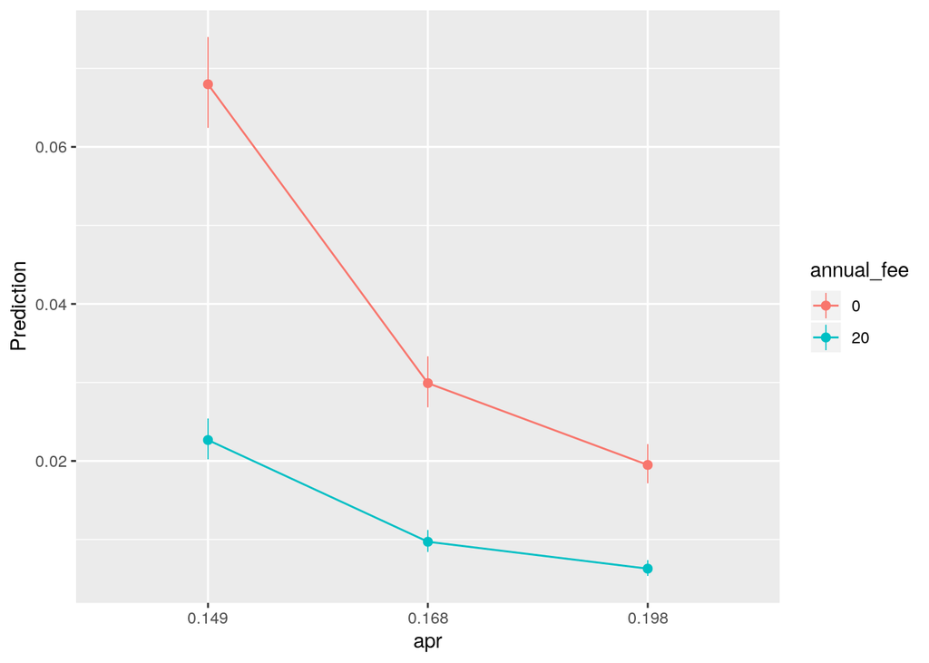

```r
## Look for potential interactions
## apr vs. annual_fee
result <- logistic(
  round1_data_gathered_dat,
  rvar = "response",
  evar = c("apr", "fixed_var", "annual_fee", "bk_score"),
  lev = "resp"
)

pred <- predict(
  result,
  pred_cmd = "apr = levels(apr), annual_fee = levels(annual_fee)"
)
plot(pred, xvar = "apr", color = "annual_fee")
```

#### Comment: Based on the above plot, apr has the small effect on the $20 annual fee but has the large effect on the no annual fee. Thus, there is an interaction between these two variables.

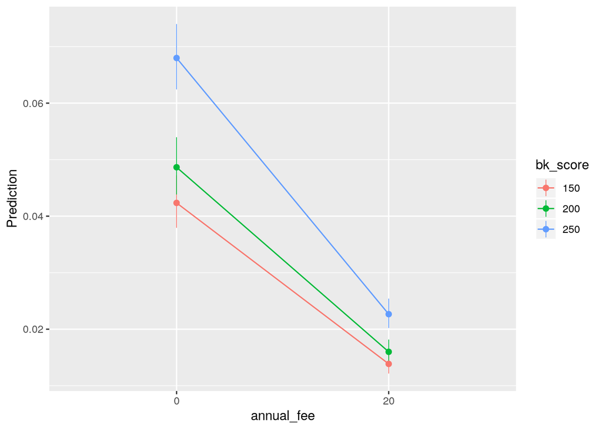

```r
## annual_fee vs. bk_score
result <- logistic(
  round1_data_gathered_dat,
  rvar = "response",
  evar = c("apr", "fixed_var", "annual_fee", "bk_score"),
  lev = "resp"
)

pred <- predict(
  result,
  pred_cmd = "annual_fee = levels(annual_fee), bk_score = levels(bk_score)"
)
plot(pred, xvar = "annual_fee", color = "bk_score")
```

#### Comment: Based on the above plot, annual_fee has the small effect on the 150 and 200 bk_scores but has the large effect on the 250 bk_score. Thus, there is an interaction between these two variables.

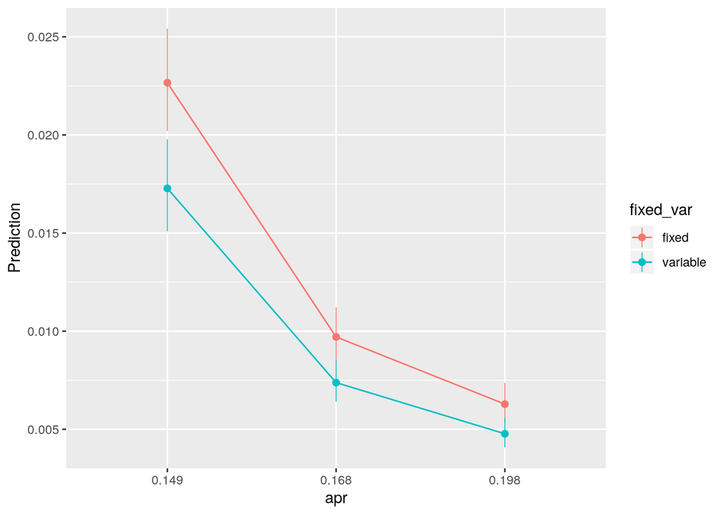

```r
## apr vs. fixed_var
result <- logistic(
  round1_data_gathered_dat,
  rvar = "response",
  evar = c("apr", "fixed_var", "annual_fee", "bk_score"),
  lev = "resp"
)

pred <- predict(
  result,
  pred_cmd = "apr = levels(apr), fixed_var = levels(fixed_var)"
)
plot(pred, xvar = "apr", color = "fixed_var")
```

#### Comment: Based on the above plot, from 16.8% to 19.8%, apr has the small effect on fixed_var, but from 14.9% to 16.8%, apr has the large effect on fixed_var. Thus, we still conclude that there is an interaction between these two variables.

```r
## Run logistic regression with 3 pairs of interaction
result_logit <- logistic(
  round1_data_gathered_dat,
  rvar = "response",
  evar = c("apr", "fixed_var", "annual_fee", "bk_score"),
  lev = "resp",
  int = c("apr:annual_fee", "annual_fee:bk_score", "apr:fixed_var")
)
summary(result_logit)
```

```
Logistic regression (GLM)
Data                 : round1_data_gathered_dat
Response variable    : response
Level                : resp in response
Explanatory variables: apr, fixed_var, annual_fee, bk_score
Null hyp.: there is no effect of x on response
Alt. hyp.: there is an effect of x on response

                                 OR coefficient std.error z.value p.value
 (Intercept)                             -3.168     0.070 -45.342  < .001 ***
 apr|0.168                    0.542      -0.612     0.079  -7.724  < .001 ***
 apr|0.198                    0.311      -1.168     0.095 -12.286  < .001 ***
 fixed_var|variable           0.532      -0.631     0.118  -5.352  < .001 ***
 annual_fee|20                0.460      -0.776     0.121  -6.433  < .001 ***
 bk_score|200                 1.070       0.067     0.092   0.731   0.465
 bk_score|250                 1.645       0.498     0.079   6.298  < .001 ***
 apr|0.168:annual_fee|20      0.417      -0.874     0.162  -5.409  < .001 ***
 apr|0.198:annual_fee|20      0.404      -0.906     0.189  -4.780  < .001 ***
 annual_fee|20:bk_score|200   1.523       0.421     0.166   2.536   0.011 *
 annual_fee|20:bk_score|250   0.871      -0.139     0.135  -1.025   0.305
 apr|0.168:fixed_var|variable 1.068       0.066     0.156   0.425   0.670
 apr|0.198:fixed_var|variable 1.494       0.401     0.168   2.383   0.017 *

Signif. codes:  0 '***' 0.001 '**' 0.01 '*' 0.05 '.' 0.1 ' ' 1

Pseudo R-squared: 0.065
Log-likelihood: -7999.696, AIC: 16025.391, BIC: 16148.528
Chi-squared: 1117.091 df(12), p.value < .001
Nr obs: 96,000
```

```r
## Get predicted probabilities and AUC on the entire dataset
pred_logit <- predict(result_logit, pred_data = round1_data_gathered_dat)
auc(pred_logit$Prediction, round1_data_gathered_dat$response)
```

```
[1] 0.7242464
```

#### Model 2: Neural Network

```r
## Baseline neural network
result_nn_base <- nn(
  round1_data_gathered_dat,
  rvar = "response",
  evar = c("apr", "fixed_var", "annual_fee", "bk_score"),
  lev = "resp",
  seed = 1234
)
summary(result_nn_base, prn = TRUE)
```

```
Neural Network
Activation function  : Logistic (classification)
Data                 : round1_data_gathered_dat
Response variable    : response
Level                : resp in response
Explanatory variables: apr, fixed_var, annual_fee, bk_score
Network size         : 1
Parameter decay      : 0.5
Seed                 : 1234
Network              : 6-1-1 with 9 weights
Nr obs               : 96,000
Weights              :
   b->h1 i1->h1 i2->h1 i3->h1 i4->h1 i5->h1 i6->h1
   -1.67   1.14   1.59   0.37   1.38  -0.15  -0.54
   b->o h1->o
  -2.39 -4.12
```

```r
## Cross-validation for neural network to get the optimal parameters in terms of maximizing AUC
## cv.nn(result, K = 5, size = 1:5, decay = seq(0.1, 0.5, 0.1), seed = 1234)
## Optimal size = 3, decay = 0.5
```

```r
## Neural network with optimal parameters
result_nn_cv <- nn(
  round1_data_gathered_dat,
  rvar = "response",
  evar = c("apr", "fixed_var", "annual_fee", "bk_score"),
  lev = "resp",
  decay = 0.5,
  size = 3,
  seed = 1234
)
summary(result_nn_cv, prn = TRUE)
```

```
Neural Network
Activation function  : Logistic (classification)
Data                 : round1_data_gathered_dat
Response variable    : response
Level                : resp in response
Explanatory variables: apr, fixed_var, annual_fee, bk_score
Network size         : 3
Parameter decay      : 0.5
Seed                 : 1234
Network              : 6-3-1 with 25 weights
Nr obs               : 96,000
Weights              :
   b->h1 i1->h1 i2->h1 i3->h1 i4->h1 i5->h1 i6->h1
    1.12  -0.76  -0.67   0.07   2.00   0.83  -0.53
   b->h2 i1->h2 i2->h2 i3->h2 i4->h2 i5->h2 i6->h2
   -0.07   0.65   1.69   1.12  -0.21  -0.52  -0.41
   b->h3 i1->h3 i2->h3 i3->h3 i4->h3 i5->h3 i6->h3
   -2.17   1.52   1.52  -0.06   1.28  -0.34  -0.22
   b->o h1->o h2->o h3->o
  -0.37 -1.93 -2.11 -3.03
```

```r
## Get predicted probabilities and AUC on the entire dataset
pred_nn <- predict(result_nn_cv, pred_data = round1_data_gathered_dat)
auc(pred_nn$Prediction, round1_data_gathered_dat$response)
```

```
[1] 0.7235992
```

#### Model 3: XGBoost

```r
## Baseline XGBoost
result_xgb_base <- gbt(
  round1_data_gathered_dat,
  rvar = "response",
  evar = c("apr", "fixed_var", "annual_fee", "bk_score"),
  lev = "resp",
  type = "classification",
  seed = 1234
)
summary(result_xgb_base, prn = TRUE)
```

```
Gradient Boosted Trees (XGBoost)
Type                 : Classification
Data                 : round1_data_gathered_dat
Response variable    : response
Level                : resp in response
Explanatory variables: apr, fixed_var, annual_fee, bk_score
Max depth            : 6
Learning rate (eta)  : 0.3
Min split loss       : 0
Min child weight     : 1
Sub-sample           : 1
Nr of rounds (trees) : 100
Early stopping rounds: 10
Seed                 : 1234
Nr obs               : 96,000

Iteration history:

...
Stopping. Best iteration:
```

```r
## Cross-validation for XGBoost to get the optimal parameters in terms of maximizing AUC
## params <- list(max_depth = 1:6, learning_rate = seq(0.1, 0.5, 0.1))
## cv.gbt(result, params = params, maximize = FALSE, trace = TRUE, seed = 1234)
## Optimal max_depth = 4, learning_rate = 0.1
```

```r
## XGBoost with optimal parameters
result_xgb_cv <- gbt(
  round1_data_gathered_dat,
  rvar = "response",
  evar = c("apr", "fixed_var", "annual_fee", "bk_score"),
  lev = "resp",
  type = "classification",
  seed = 1234,
  max_depth = 4,
  learning_rate = 0.1
)
summary(result_xgb_cv, prn = TRUE)
```

```
Gradient Boosted Trees (XGBoost)
Type                 : Classification
Data                 : round1_data_gathered_dat
Response variable    : response
Level                : resp in response
Explanatory variables: apr, fixed_var, annual_fee, bk_score
Max depth            : 4
Learning rate (eta)  : 0.1
Min split loss       : 0
Min child weight     : 1
Sub-sample           : 1
Nr of rounds (trees) : 100
Early stopping rounds: 10
Seed                 : 1234
Nr obs               : 96,000

Iteration history:

...
Stopping. Best iteration:
```

```r
## Get predicted probabilities and AUC on the entire dataset
pred_xgb <- predict(result_xgb_cv, pred_data = round1_data_gathered_dat)
auc(pred_xgb$Prediction, round1_data_gathered_dat$response)
```

```
[1] 0.725292
```

#### Comparison of 3 Models Based on AUC

```r
## Create the tibble
AUC_tibble <- tibble::tibble(
  Model = c("Logistic Regression", "Neural Network", "XGBoost"),
  AUC = c(0.7242464, 0.7235992, 0.725292)) %>%
  mutate(Model = factor(Model, levels = Model))
arrange(AUC_tibble, desc(AUC))
```

```
# A tibble: 3 x 2
  Model                 AUC
  <fct>               <dbl>
1 XGBoost             0.725
2 Logistic Regression 0.724
3 Neural Network      0.724
```

#### Comment: Based on the AUC tibble, the AUC of XGBoost is only a little higher than Logistic Regression (about 0.001 = 0.1%), so it not better enough to choose XGBoost. Therefore, we choose Logistic Regression to do following predictions for easier understanding and interpretation.

#### Prediction

```r
## Gather columns
exhibit2_gathered <- gather(exhibit2, clv_bk, clv, clv150, clv200, clv250, factor_key = TRUE)

## Create new variable(s)
exhibit2_gathered <- mutate(exhibit2_gathered, bk_score = ifelse(clv_bk == "clv150", 150, ifelse(clv_bk == "clv200", 200, 250)))

## Change variable type
exhibit2_gathered <- mutate_at(exhibit2_gathered, .vars = vars(bk_score), .funs = as_factor)

## Make fixed_var as lower case
exhibit2_gathered$fixed_var <- tolower(exhibit2_gathered$fixed_var)

## Make apr, fixed_var, and annual_fee as factor
exhibit2_gathered$apr <- as.factor(exhibit2_gathered$apr / 100)
exhibit2_gathered$fixed_var <- as.factor(exhibit2_gathered$fixed_var)
exhibit2_gathered$annual_fee <- as.factor(exhibit2_gathered$annual_fee)
```

```r
## Predict the response rate on the 36 full combinations
pred_resp <- predict(result_logit, pred_data = exhibit2_gathered)
pred_resp$clv <- exhibit2_gathered$clv
pred_resp$margin <- pred_resp$Prediction * pred_resp$clv
pred_resp %>%
  arrange(desc(margin)) %>%
  slice(1:18)
```

```
     apr fixed_var annual_fee bk_score Prediction        2.5%      97.5% clv    margin
1  0.149     fixed          0      150 0.04039865 0.035411964 0.04605403  52 2.1007297
2  0.149     fixed         20      200 0.03060636 0.023463331 0.03983527  63 1.9282009
3  0.168     fixed          0      150 0.02232624 0.018461467 0.02697784  72 1.6074893
4  0.149     fixed         20      150 0.01900580 0.015725525 0.02295437  83 1.5774813
5  0.149     fixed          0      200 0.04309292 0.038117039 0.04868548  32 1.3789733
6  0.149  variable          0      150 0.02189799 0.016850630 0.02841351  62 1.3576752
7  0.198     fixed          0      150 0.01292364 0.010404329 0.01604308 100 1.2923636
8  0.168     fixed          0      200 0.02384517 0.020547300 0.02765741  52 1.2399489
9  0.149  variable         20      200 0.01651294 0.013468154 0.02023194  73 1.2054443
10 0.198  variable          0      150 0.01029188 0.008378667 0.01263641 110 1.1321073
11 0.198     fixed          0      200 0.01381191 0.011513558 0.01656138  80 1.1049530
12 0.198     fixed          0      250 0.02108034 0.017822258 0.02491892  50 1.0540169
13 0.168  variable          0      150 0.01280947 0.010604957 0.01546508  82 1.0503763
14 0.198  variable          0      250 0.01681586 0.013934375 0.02028096  60 1.0089518
15 0.198  variable          0      200 0.01100129 0.008793854 0.01375515  90 0.9901161
16 0.149  variable          0      200 0.02338848 0.018028895 0.03029220  42 0.9823162
17 0.149  variable         20      150 0.01019793 0.008207870 0.01266434  93 0.9484077
18 0.149     fixed         20      250 0.02699420 0.022841858 0.03187676  33 0.8908086
```

#### 4. For each bk_score group, send 20% (20% * 226,000 = 45,200) of remaining mailings to the combination that generate the third highest margin.